# Figure 4

Steve Pederson

29 March 2016

# Introduction

This contains code for the generation of Figure 4, S5 and S6

# Setup

```r
library(ggplot2)
library(stringr)
library(reshape2)
library(matrixStats)
library(VennDiagram)
library(knitr)
library(xtable)
library(corrplot)
library(scales)
library(boot)
library(lmtest)
library(dplyr)
library(magrittr)
library(parallel)
library(funsForLu)
library(spShortcuts)
library(multcomp)
```

Load the data

```r
tpmFile <- file.path("data", "Figure4.txt")
tpmData <- read.delim(tpmFile, sep="\t", stringsAsFactors = FALSE) %>%
  dplyr::select(ID, length, contains("TPM"), contains("IDs")) %>%
  tbl_df
```

Collect the elements by type and region

```r
elements <- grep("IDs", colnames(tpmData), value = TRUE) %>%
  str_split_fixed(pattern="_", 3) %>%
  as.data.frame(stringsAsFactors = FALSE) %>%
  dplyr::select(type = V1, region = V2) %>%
  lapply(unique) %>%
  lapply(sort)
nRegions <- length(elements$region)
nElements <- length(elements$type)
regFactor <- c("Proximal\nPromoter", "5'UTR", "CDS", "3'UTR")
```

Collect the tissues

```r
tissues <- colnames(tpmData) %>%
  str_subset("TPM") %>%
  str_replace("_TPM", "")
nTissues <- length(tissues)
```

Add columns of logical values to the main data object which denote the element type and region

```r
tpmData %<>%
  bind_cols(sapply(unlist(elements) %>%
                     as.vector,
                   function(x){dplyr::select(tpmData, contains(x)) %>%
                                 rowSums %>%
                                 as.logical},
                   simplify = FALSE)) %>%
  mutate(nElTypes = alu + L1 + L2 + LTR + mir)
```

Add further columns which convert the log(TPM) values to binary `TRUE` or `FALSE` variables for gene expression. Genes for which log(TPM)$=-\infty$ have TPM$=0$ and will be set to `FALSE`

```r
tpmData %<>%
  mutate(adipose_TF = as.logical(exp(adipose_TPM)),
         brain_TF = as.logical(exp(brain_TPM)),
         liver_TF = as.logical(exp(liver_TPM)),
         skeletal_muscle_TF = as.logical(exp(skeletal_muscle_TPM)),
         testes_TF = as.logical(exp(testes_TPM)),
         kidney_TF = as.logical(exp(kidney_TPM)))
```

# Setup For The Bootstrap Procedure

Additionally, a number of genes contained all five elements, and as this set of 1722 genes was clearly higher than would be expected by random, this set with all 5 elements were omitted from the analysis.

```r
nBins <- 10
tpmData %<>%
  filter(nElTypes != nElements) %>%
  mutate(lengthBin = findInterval(length,
                                  quantile(length,
                                           probs = seq(0, 1, length.out = nBins + 1)),
                                  rightmost.closed=TRUE),
         logLength = log(length))
```

Confidence intervals will be formed for the difference in the probability of a gene being expressed, and for the difference in expression levels due to the presence of each TE within each Genomic Region. However, in order to control the Type 1 Error at the level $\alpha = 0.05$, each set of $m$ intervals needs to be adjusted, with Bonferroni’s method being the simplest approach. Thus a set of $1-\alpha / m$ Confidence intervals will be formed for each genomic region.

```r
m <- nTissues*nElements*nRegions
alpha <- 0.05/m
nBoot <- 10000L
testVals <- c("logLength",
              paste0(tissues, "_TPM"),
              paste0(tissues, "_TF"))
```

In order to provide the number of samples to accurately construct these confidence intervals, the analysis was performed using 10000 bootstrap iterations.

# The bootstrap procedure

## 3’ UTR

### Alu Elements

```r
aluUtr3Data <- tpmData %>%
  mutate(
    elBins = dplyr::select(
      tpmData,
      one_of(grep("alu", elements$type, invert = TRUE, value = TRUE))
    ) %>%
    binsFromCols,
    elBins = paste(elBins, lengthBin, sep = "_")) %>%
  filter(alu_cds_IDs == 0,
         alu_prox_IDs == 0,
         alu_utr5_IDs == 0)
```

```r
bootAluUtr3 <- mclapply(testVals,
                        bootMeans,
                        data = aluUtr3Data,
                        testIds = filter(aluUtr3Data, alu)$ID,
                        refIds = filter(aluUtr3Data, !alu)$ID,
                        binCol = "elBins",
                        nBoot = nBoot,
                        nGenes = 1000L,
                        maxP = 0.01)
names(bootAluUtr3) <- testVals
```

### L1 Elements

```r
L1Utr3Data <- tpmData %>%
  mutate(
    elBins = dplyr::select(
      tpmData,
      one_of(grep("L1", elements$type, invert = TRUE, value = TRUE))
    ) %>%
    binsFromCols,
    elBins = paste(elBins, lengthBin, sep = "_")) %>%
  filter(L1_cds_IDs == 0,
         L1_prox_IDs == 0,
         L1_utr5_IDs == 0)
```

```r
bootL1Utr3 <- mclapply(testVals,
                        bootMeans,
                        data = L1Utr3Data,
                        testIds = filter(L1Utr3Data, L1)$ID,
                        refIds = filter(L1Utr3Data, !L1)$ID,
                        binCol = "elBins",
                        nBoot = nBoot,
                        nGenes = 1000L,
                        maxP = 0.01)
names(bootL1Utr3) <- testVals
```

### L2 Elements

```r
L2Utr3Data <- tpmData %>%
  mutate(
    elBins = dplyr::select(
      tpmData,
      one_of(grep("L2", elements$type, invert = TRUE, value = TRUE))
    ) %>%
    binsFromCols,
    elBins = paste(elBins, lengthBin, sep = "_")) %>%
  filter(L2_cds_IDs == 0,
         L2_prox_IDs == 0,
         L2_utr5_IDs == 0)
```

```r
bootL2Utr3 <- mclapply(testVals,
                        bootMeans,
                        data = L2Utr3Data,
                        testIds = filter(L2Utr3Data, L2)$ID,
                        refIds = filter(L2Utr3Data, !L2)$ID,
                        binCol = "elBins",
                        nBoot = nBoot,
                        nGenes = 1000L,
                        maxP = 0.01)
names(bootL2Utr3) <- testVals
```

### LTR Elements

```r
LTRUtr3Data <- tpmData %>%
  mutate(
    elBins = dplyr::select(
      tpmData,
      one_of(grep("LTR", elements$type, invert = TRUE, value = TRUE))
    ) %>%
    binsFromCols,
    elBins = paste(elBins, lengthBin, sep = "_")) %>%
  filter(LTR_cds_IDs == 0,
         LTR_prox_IDs == 0,
         LTR_utr5_IDs == 0)
```

```r
bootLTRUtr3 <- mclapply(testVals,
                        bootMeans,
                        data = LTRUtr3Data,
                        testIds = filter(LTRUtr3Data, LTR)$ID,
                        refIds = filter(LTRUtr3Data, !LTR)$ID,
                        binCol = "elBins",
                        nBoot = nBoot,
                        nGenes = 1000L,
                        maxP = 0.01)
names(bootLTRUtr3) <- testVals
```

### mir Elements

```r
mirUtr3Data <- tpmData %>%
  mutate(
    elBins = dplyr::select(
      tpmData,
      one_of(grep("mir", elements$type, invert = TRUE, value = TRUE))
    ) %>%
    binsFromCols,
    elBins = paste(elBins, lengthBin, sep = "_")) %>%
  filter(mir_cds_IDs == 0,
         mir_prox_IDs == 0,
         mir_utr5_IDs == 0)
```

```r
bootMirUtr3 <- mclapply(testVals,
                        bootMeans,
                        data = mirUtr3Data,
                        testIds = filter(mirUtr3Data, mir)$ID,
                        refIds = filter(mirUtr3Data, !mir)$ID,
                        binCol = "elBins",
                        nBoot = nBoot,
                        nGenes = 1000L,
                        maxP = 0.01)
names(bootMirUtr3) <- testVals
```

## 5’ UTR

### Alu Elements

```r
aluUtr5Data <- tpmData %>%
  mutate(
    elBins = dplyr::select(
      tpmData,
      one_of(grep("alu", elements$type, invert = TRUE, value = TRUE))
    ) %>%
    binsFromCols,
    elBins = paste(elBins, lengthBin, sep = "_")) %>%
  filter(alu_cds_IDs == 0,
         alu_prox_IDs == 0,
         alu_utr3_IDs == 0)
```

```r
bootAluUtr5 <- mclapply(testVals,
                        bootMeans,
                        data = aluUtr5Data,
                        testIds = filter(aluUtr5Data, alu)$ID,
                        refIds = filter(aluUtr5Data, !alu)$ID,
                        binCol = "elBins",
                        nBoot = nBoot,
                        nGenes = 1000L,
                        maxP = 0.01)
names(bootAluUtr5) <- testVals
```

### L1 Elements

```r
L1Utr5Data <- tpmData %>%
  mutate(
    elBins = dplyr::select(
      tpmData,
      one_of(grep("L1", elements$type, invert = TRUE, value = TRUE))
    ) %>%
    binsFromCols,
    elBins = paste(elBins, lengthBin, sep = "_")) %>%
  filter(L1_cds_IDs == 0,
         L1_prox_IDs == 0,
         L1_utr3_IDs == 0)
```

```r
bootL1Utr5 <- mclapply(testVals,
                        bootMeans,
                        data = L1Utr5Data,
                        testIds = filter(L1Utr5Data, L1)$ID,
                        refIds = filter(L1Utr5Data, !L1)$ID,
                        binCol = "elBins",
                        nBoot = nBoot,
                        nGenes = 1000L,
                        maxP = 0.01)
names(bootL1Utr5) <- testVals
```

### L2 Elements

```r
L2Utr5Data <- tpmData %>%
  mutate(
    elBins = dplyr::select(
      tpmData,
      one_of(grep("L2", elements$type, invert = TRUE, value = TRUE))
    ) %>%
    binsFromCols,
    elBins = paste(elBins, lengthBin, sep = "_")) %>%
  filter(L2_cds_IDs == 0,
         L2_prox_IDs == 0,
         L2_utr3_IDs == 0)
```

```r
bootL2Utr5 <- mclapply(testVals,
                        bootMeans,
                        data = L2Utr5Data,
                        testIds = filter(L2Utr5Data, L2)$ID,
                        refIds = filter(L2Utr5Data, !L2)$ID,
                        binCol = "elBins",
                        nBoot = nBoot,
                        nGenes = 1000L,
                        maxP = 0.01)
names(bootL2Utr5) <- testVals
```

### LTR Elements

```r
LTRUtr5Data <- tpmData %>%
  mutate(
    elBins = dplyr::select(
      tpmData,
      one_of(grep("LTR", elements$type, invert = TRUE, value = TRUE))
    ) %>%
    binsFromCols,
    elBins = paste(elBins, lengthBin, sep = "_")) %>%
  filter(LTR_cds_IDs == 0,
         LTR_prox_IDs == 0,
         LTR_utr3_IDs == 0)
```

```r
bootLTRUtr5 <- mclapply(testVals,
                        bootMeans,
                        data = LTRUtr5Data,
                        testIds = filter(LTRUtr5Data, LTR)$ID,
                        refIds = filter(LTRUtr5Data, !LTR)$ID,
                        binCol = "elBins",
                        nBoot = nBoot,
                        nGenes = 1000L,
                        maxP = 0.01)
names(bootLTRUtr5) <- testVals
```

### mir Elements

```r
mirUtr5Data <- tpmData %>%
  mutate(
    elBins = dplyr::select(
      tpmData,
      one_of(grep("mir", elements$type, invert = TRUE, value = TRUE))
    ) %>%
    binsFromCols,
    elBins = paste(elBins, lengthBin, sep = "_")) %>%
  filter(mir_cds_IDs == 0,
         mir_prox_IDs == 0,
         mir_utr3_IDs == 0)
```

```r
bootMirUtr5 <- mclapply(testVals,
                        bootMeans,
                        data = mirUtr5Data,
                        testIds = filter(mirUtr5Data, mir)$ID,
                        refIds = filter(mirUtr5Data, !mir)$ID,
                        binCol = "elBins",
                        nBoot = nBoot,
                        nGenes = 1000L,
                        maxP = 0.01)
names(bootMirUtr5) <- testVals
```

## Proximal Promoter

### Alu Elements

```r
aluProxData <- tpmData %>%
  mutate(
    elBins = dplyr::select(
      tpmData,
      one_of(grep("alu", elements$type, invert = TRUE, value = TRUE))
    ) %>%
    binsFromCols,
    elBins = paste(elBins, lengthBin, sep = "_")) %>%
  filter(alu_cds_IDs == 0,
         alu_utr3_IDs == 0,
         alu_utr5_IDs == 0)
```

```r
bootAluProx <- mclapply(testVals,
                        bootMeans,
                        data = aluProxData,
                        testIds = filter(aluProxData, alu)$ID,
                        refIds = filter(aluProxData, !alu)$ID,
                        binCol = "elBins",
                        nBoot = nBoot,
                        nGenes = 1000L,
                        maxP = 0.01)
names(bootAluProx) <- testVals
```

### L1 Elements

```r
L1ProxData <- tpmData %>%
  mutate(
    elBins = dplyr::select(
      tpmData,
      one_of(grep("L1", elements$type, invert = TRUE, value = TRUE))
    ) %>%
    binsFromCols,
    elBins = paste(elBins, lengthBin, sep = "_")) %>%
  filter(L1_cds_IDs == 0,
         L1_utr3_IDs == 0,
         L1_utr5_IDs == 0)
```

```r
bootL1Prox <- mclapply(testVals,
                        bootMeans,
                        data = L1ProxData,
                        testIds = filter(L1ProxData, L1)$ID,
                        refIds = filter(L1ProxData, !L1)$ID,
                        binCol = "elBins",
                        nBoot = nBoot,
                        nGenes = 1000L,
                        maxP = 0.01)
names(bootL1Prox) <- testVals
```

### L2 Elements

```r
L2ProxData <- tpmData %>%
  mutate(
    elBins = dplyr::select(
      tpmData,
      one_of(grep("L2", elements$type, invert = TRUE, value = TRUE))
    ) %>%
    binsFromCols,
    elBins = paste(elBins, lengthBin, sep = "_")) %>%
  filter(L2_cds_IDs == 0,
         L2_utr3_IDs == 0,
         L2_utr5_IDs == 0)
```

```r
bootL2Prox <- mclapply(testVals,
                        bootMeans,
                        data = L2ProxData,
                        testIds = filter(L2ProxData, L2)$ID,
                        refIds = filter(L2ProxData, !L2)$ID,
                        binCol = "elBins",
                        nBoot = nBoot,
                        nGenes = 1000L,
                        maxP = 0.01)
names(bootL2Prox) <- testVals
```

### LTR Elements

```r
LTRProxData <- tpmData %>%
  mutate(
    elBins = dplyr::select(
      tpmData,
      one_of(grep("LTR", elements$type, invert = TRUE, value = TRUE))
    ) %>%
    binsFromCols,
    elBins = paste(elBins, lengthBin, sep = "_")) %>%
  filter(LTR_cds_IDs == 0,
         LTR_utr3_IDs == 0,
         LTR_utr5_IDs == 0)
```

```r
bootLTRProx <- mclapply(testVals,
                        bootMeans,
                        data = LTRProxData,
                        testIds = filter(LTRProxData, LTR)$ID,
                        refIds = filter(LTRProxData, !LTR)$ID,
                        binCol = "elBins",
                        nBoot = nBoot,
                        nGenes = 1000L,
                        maxP = 0.01)
names(bootLTRProx) <- testVals
```

### mir Elements

```r
mirProxData <- tpmData %>%
  mutate(
    elBins = dplyr::select(
      tpmData,
      one_of(grep("mir", elements$type, invert = TRUE, value = TRUE))
    ) %>%
    binsFromCols,
    elBins = paste(elBins, lengthBin, sep = "_")) %>%
  filter(mir_cds_IDs == 0,
         mir_utr3_IDs == 0,
         mir_utr5_IDs == 0)
```

```r
bootMirProx <- mclapply(testVals,
                        bootMeans,
                        data = mirProxData,
                        testIds = filter(mirProxData, mir)$ID,
                        refIds = filter(mirProxData, !mir)$ID,
                        binCol = "elBins",
                        nBoot = nBoot,
                        nGenes = 1000L,
                        maxP = 0.01)
names(bootMirProx) <- testVals
```

## CDS regions

### Alu Elements

```r
aluCDSData <- tpmData %>%
  mutate(
    elBins = dplyr::select(
      tpmData,
      one_of(grep("alu", elements$type, invert = TRUE, value = TRUE))
    ) %>%
    binsFromCols,
    elBins = paste(elBins, lengthBin, sep = "_")) %>%
  filter(alu_prox_IDs == 0,
         alu_utr3_IDs == 0,
         alu_utr5_IDs == 0)
```

```r
bootAluCDS <- mclapply(testVals,
                        bootMeans,
                        data = aluCDSData,
                        testIds = filter(aluCDSData, alu)$ID,
                        refIds = filter(aluCDSData, !alu)$ID,
                        binCol = "elBins",
                        nBoot = nBoot,
                        nGenes = 45L,
                        maxP = 0.1)
names(bootAluCDS) <- testVals
```

### L1 Elements

```r
L1CDSData <- tpmData %>%
  mutate(
    elBins = dplyr::select(
      tpmData,
      one_of(grep("L1", elements$type, invert = TRUE, value = TRUE))
    ) %>%
    binsFromCols,
    elBins = paste(elBins, lengthBin, sep = "_")) %>%
  filter(L1_prox_IDs == 0,
         L1_utr3_IDs == 0,
         L1_utr5_IDs == 0)
```

```r
bootL1CDS <- mclapply(testVals,
                        bootMeans,
                        data = L1CDSData,
                        testIds = filter(L1CDSData, L1)$ID,
                        refIds = filter(L1CDSData, !L1)$ID,
                        binCol = "elBins",
                        nBoot = nBoot,
                        nGenes = 45L,
                        maxP = 0.1)
names(bootL1CDS) <- testVals
```

### L2 Elements

```r
L2CDSData <- tpmData %>%
  mutate(
    elBins = dplyr::select(
      tpmData,
      one_of(grep("L2", elements$type, invert = TRUE, value = TRUE))
    ) %>%
    binsFromCols,
    elBins = paste(elBins, lengthBin, sep = "_")) %>%
  filter(L2_prox_IDs == 0,
         L2_utr3_IDs == 0,
         L2_utr5_IDs == 0)
```

```r
bootL2CDS <- mclapply(testVals,
                        bootMeans,
                        data = L2CDSData,
                        testIds = filter(L2CDSData, L2)$ID,
                        refIds = filter(L2CDSData, !L2)$ID,
                        binCol = "elBins",
                        nBoot = nBoot,
                        nGenes = 55L,
                        maxP = 0.1)
names(bootL2CDS) <- testVals
```

### LTR Elements

```r
LTRCDSData <- tpmData %>%
  mutate(
    elBins = dplyr::select(
      tpmData,
      one_of(grep("LTR", elements$type, invert = TRUE, value = TRUE))
    ) %>%
    binsFromCols,
    elBins = paste(elBins, lengthBin, sep = "_")) %>%
  filter(LTR_prox_IDs == 0,
         LTR_utr3_IDs == 0,
         LTR_utr5_IDs == 0)
```

```r
bootLTRCDS <- mclapply(testVals,
                        bootMeans,
                        data = LTRCDSData,
                        testIds = filter(LTRCDSData, LTR)$ID,
                        refIds = filter(LTRCDSData, !LTR)$ID,
                        binCol = "elBins",
                        nBoot = nBoot,
                        nGenes = 33L,
                        maxP = 0.01)
names(bootLTRCDS) <- testVals
```

### mir Elements

```r
mirCDSData <- tpmData %>%
  mutate(
    elBins = dplyr::select(
      tpmData,
      one_of(grep("mir", elements$type, invert = TRUE, value = TRUE))
    ) %>%
    binsFromCols,
    elBins = paste(elBins, lengthBin, sep = "_")) %>%
  filter(mir_prox_IDs == 0,
         mir_utr3_IDs == 0,
         mir_utr5_IDs == 0)
```

```r
bootMirCDS <- mclapply(testVals,
                        bootMeans,
                        data = mirCDSData,
                        testIds = filter(mirCDSData, mir)$ID,
                        refIds = filter(mirCDSData, !mir)$ID,
                        binCol = "elBins",
                        nBoot = nBoot,
                        nGenes = 35L,
                        maxP = 0.1)
names(bootMirCDS) <- testVals
```

# Confidence Intervals for Length Differences

This step is a control to check that the length distributions were suitably paired. Any intervals that don’t contain zero will indicate that the two sets of genes will have different length distributions and the comparison will need to be reanalysed

```r
allBoot<- list(bootAluUtr3, bootAluUtr5, bootAluProx, bootAluCDS,
               bootL1Utr3, bootL1Utr5, bootL1Prox, bootL1CDS,
               bootL2Utr3, bootL2Utr5, bootL2Prox, bootL2CDS,
               bootLTRUtr3, bootLTRUtr5, bootLTRProx, bootLTRCDS,
               bootMirUtr3, bootMirUtr5, bootMirProx, bootMirCDS) %>%
  set_names(elements$type %>%
              vapply(function(x){
                paste0(x, c("Utr3", "Utr5", "Prox", "CDS"))
              },
              character(4)) %>%
              as.vector())
```

```r
confIntLen <- allBoot %>%
  lapply(extract, "logLength") %>%
  lapply(getCI, alpha = 0.05, combined = TRUE) %>%
  bind_rows %>%
  mutate(Region = rep(c("3'UTR", "5'UTR","Proximal Promoter", "CDS"),
                      times = nElements),
         TE = rep(elements$type, each = nRegions))
```

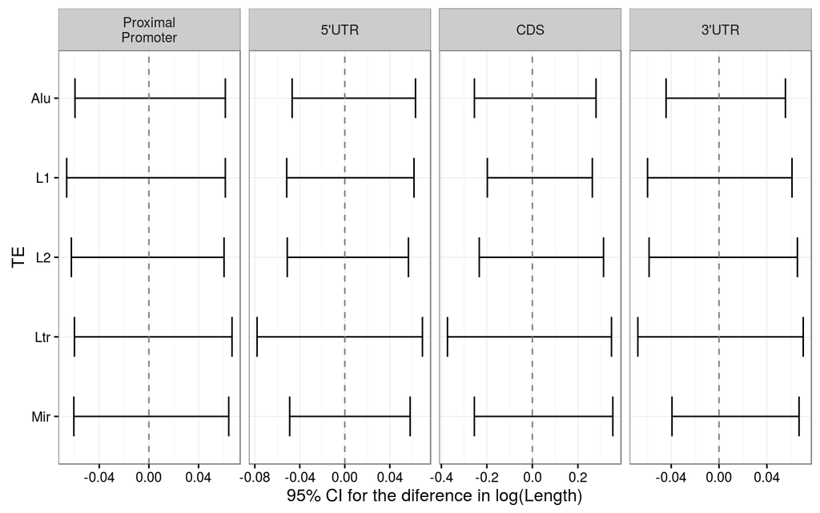

As type II errors are the primary concern here, no adjustment was applied for multiple comparisons. Zero didn’t lie outside of any of these intervals, and as such the subsequent results for the bootstrap can be deemed to be valid.

# Confidence Intervals for Elements & Regions

## Differences in the Probability of Gene Expression

```r
m <- nRegions*nElements*nTissues
confIntExProbs <- allBoot %>%
  lapply(extract, paste0(tissues, "_TF")) %>%
  lapply(getCI,
         alpha = 0.05/m,
         combined = FALSE) %>%
  bind_rows() %>%
  mutate(TE = rep(elements$type,
                  each = nRegions*nTissues),
         TE = capwords(TE),
         TE = gsub("Ltr", "LTR", TE),
         Region = c("3'UTR", "5'UTR", "Proximal\nPromoter", "CDS") %>%
           rep(times =nElements) %>%
           rep(each = nTissues),
         Region = factor(Region, levels= regFactor),
         Sig = sign(lower) == sign(upper),
         Tissue = capwords(Tissue, sep = "_"),
         Tissue = gsub(" Tf", "", Tissue),
         Tissue = factor(Tissue, rev(unique(sort(Tissue)))),
         lower = lower/log(2),
         median = median / log(2),
         upper = upper / log(2))
```

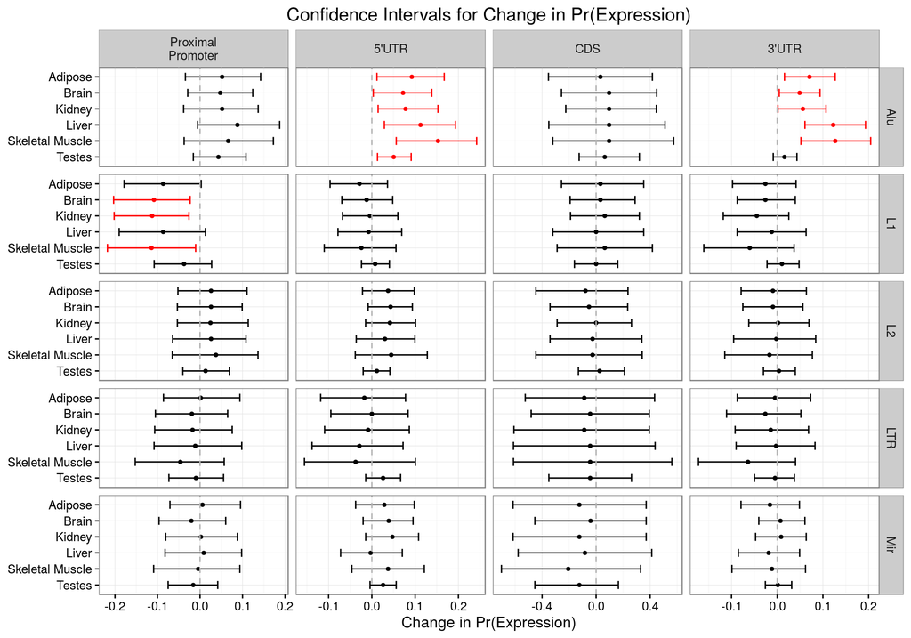

## Effects on Gene Expression

As there appeared to be a bias towards upregulatory effects due to the presence of an Alu element, tissue-specific effects were investigated for all elements

```r
m <- nRegions*nElements*nTissues
confIntTissues <- allBoot %>%
  lapply(extract, paste0(tissues, "_TPM")) %>%
  lapply(getCI,
         alpha = 0.05/m) %>%
  bind_rows() %>%
  mutate(TE = rep(elements$type,
                  each = nRegions*nTissues),
         Region = c("3'UTR", "5'UTR", "Proximal\nPromoter", "CDS") %>%
           rep(times =nElements) %>%
           rep(each = nTissues),
         Sig = sign(lower) == sign(upper))
```

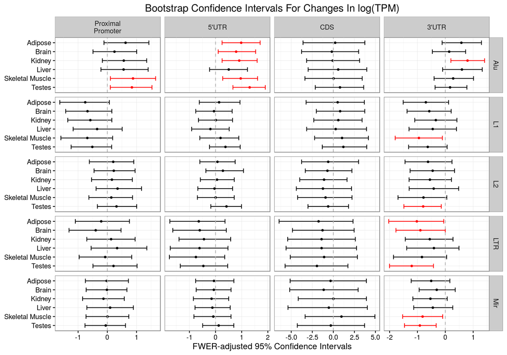

```r
confIntTissuesNoAdj <- allBoot %>%
  lapply(extract, paste0(tissues, "_TPM")) %>%
  lapply(getCI,
         alpha = 0.05) %>%
  bind_rows() %>%
  mutate(TE = rep(elements$type,
                  each = nRegions*nTissues),
         Region = c("3'UTR", "5'UTR", "Proximal\nPromoter", "CDS") %>%
           rep(times =nElements) %>%
           rep(each = nTissues),
         Sig = sign(lower) == sign(upper))
```

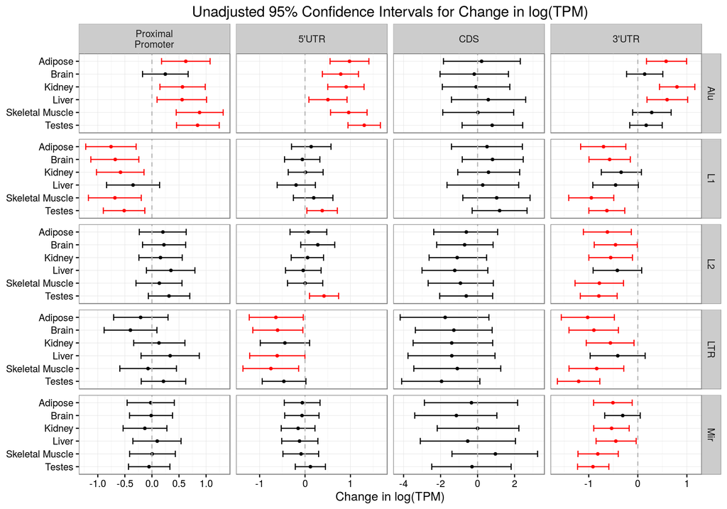

```r
save.image("Figure4.RData")
```